# DSC 462, Homework 4

Kefu Zhu

11/21/2018

```r
library(MASS)
```

# Question 1

## (a)

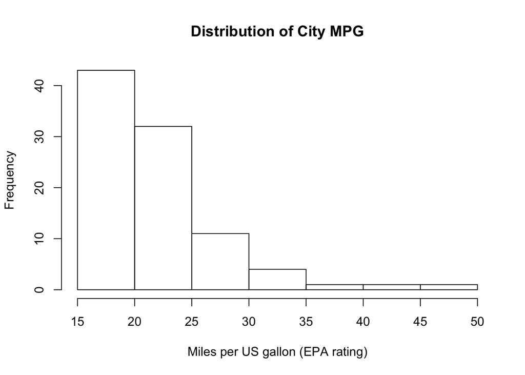

```r
hist(Cars93$MPG.city,
     main = 'Distribution of City MPG',
     xlab = 'Miles per US gallon (EPA rating)')
```

**Answer**: It is clear to see the distribution of `MPG.city` is right skewed

## (b)

```r
empirical_rule = function(x) {
  # Initialize the output 3x2 matrix with zeros
  result = matrix(0,
                  nrow = 3,
                  ncol = 2,
                  dimnames = list(c('within 1 SD',
                                    'within 2 SD',
                                    'within 3 SD'),
                                  c('Sample Proportion (%)',
                                    'Theoretical Proportion (%)'))
                  )
  # Insert the theoretical values
  result[, 'Theoretical Proportion (%)'] = c(68, 95, 99.7)

  # Compute the mean and sample standard deviation
  sample_sd = sd(x)
  sample_mean = mean(x)

  # Compute the sample proportion and insert them into the matrix
  result[1, 'Sample Proportion (%)'] = 100 * sum(abs(x - mean(x)) < 1 * sample_sd) / length(x)
  result[2, 'Sample Proportion (%)'] = 100 * sum(abs(x - mean(x)) < 2 * sample_sd) / length(x)
  result[3, 'Sample Proportion (%)'] = 100 * sum(abs(x - mean(x)) < 3 * sample_sd) / length(x)

  # Return the matrix
  return(result)
}
```

### Test on Random Sample

#### Normal Distribution

```r
normal_sample = rnorm(1000)
empirical_rule(normal_sample)
```

```
##             Sample Proportion (%) Theoretical Proportion (%)
## within 1 SD                  70.1                       68.0
## within 2 SD                  95.0                       95.0
## within 3 SD                  99.5                       99.7
```

#### Exponential Distribution

```r
exp_sample = rexp(1000)
empirical_rule(exp_sample)
```

```
##             Sample Proportion (%) Theoretical Proportion (%)
## within 1 SD                  89.0                       68.0
## within 2 SD                  95.8                       95.0
## within 3 SD                  98.4                       99.7
```

#### Uniform Distribution

```r
uniform_sample = runif(1000)
empirical_rule(uniform_sample)
```

```
##             Sample Proportion (%) Theoretical Proportion (%)
## within 1 SD                  57.9                       68.0
## within 2 SD                 100.0                       95.0
## within 3 SD                 100.0                       99.7
```

## (c)

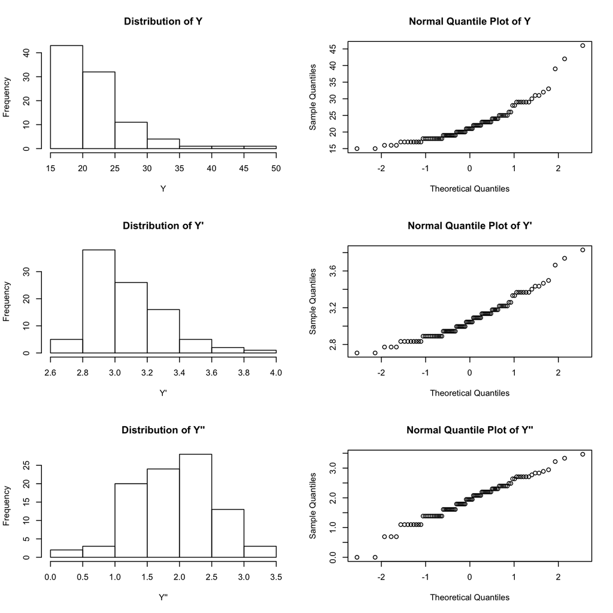

```r
# Set 3x2 plot grid
par(mfrow=c(3,2))
# Set Y
y = Cars93$MPG.city

# Histogram for Y
hist(y, main = 'Distribution of Y', xlab = 'Y')
# Normal Quantile Plot for Y
qqnorm(y, main = 'Normal Quantile Plot of Y')

# Computer Y'
y_prime = log(y)
# Histogram for Y'
hist(y_prime, main = "Distribution of Y'", xlab = "Y'")
# Normal Quantile Plot for Y
qqnorm(y_prime, main = "Normal Quantile Plot of Y'")

# Computer Y''
y_double_prime = log(y - min(y) + 1)
# Histogram for Y'
hist(y_double_prime, main = "Distribution of Y''", xlab = "Y''")
# Normal Quantile Plot for Y
qqnorm(y_double_prime, main = "Normal Quantile Plot of Y''")
```

```r
# Reset the plot grid setting
dev.off()
```

```r
empirical_rule(y)
```

```
##             Sample Proportion (%) Theoretical Proportion (%)
## within 1 SD              77.41935                       68.0
## within 2 SD              96.77419                       95.0
## within 3 SD              97.84946                       99.7
```

```r
empirical_rule(y_prime)
```

```
##             Sample Proportion (%) Theoretical Proportion (%)
## within 1 SD              68.81720                       68.0
## within 2 SD              96.77419                       95.0
## within 3 SD              98.92473                       99.7
```

```r
empirical_rule(y_double_prime)
```

```
##             Sample Proportion (%) Theoretical Proportion (%)
## within 1 SD              68.81720                       68.0
## within 2 SD              95.69892                       95.0
## within 3 SD             100.00000                       99.7
```

**Answer**: Only the transformation, $Y^{''} = log(Y - min(Y) + 1)$, is close enough to be approximated to normal distribution

# Question 2

## (a)

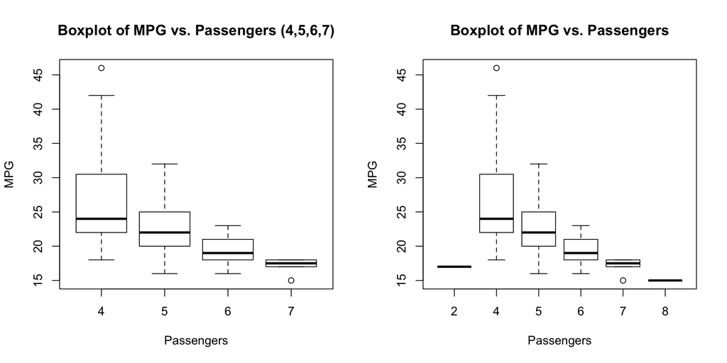

```r
# Set 1x2 plot grid
par(mfrow=c(1,2))
# Subset data
newdata = subset(Cars93, Cars93$Passengers %in% c(4,5,6,7))

# Boxplot for Passengers equal to 4,5,6,7
boxplot(
  MPG.city ~ Passengers,
  data = newdata,
  main = 'Boxplot of MPG vs. Passengers (4,5,6,7)',
  xlab = 'Passengers',
  ylab = 'MPG'
  )

# Boxplot for all data
boxplot(
  MPG.city ~ Passengers,
  Cars93,
  main = 'Boxplot of MPG vs. Passengers',
  xlab = 'Passengers',
  ylab = 'MPG'
  )
```

```r
# Reset the plot grid setting
dev.off()
```

**Answer**: From the above two boxplots, most of the data are from cars with passenger capacity of 4,5,6,7. Only few observations are from cars with passenger capacity of 2 or 8 people. In addition, the mean value of MPG value and its variation also varies quite a lot in different groups (Cars that has different passenger capacity).

## (b)

```r
# Compute mean value of MPG for different group
mean_4 = mean(Cars93[Cars93$Passengers == 4,'MPG.city'])
mean_5 = mean(Cars93[Cars93$Passengers == 5,'MPG.city'])
mean_6 = mean(Cars93[Cars93$Passengers == 6,'MPG.city'])
mean_7 = mean(Cars93[Cars93$Passengers == 7,'MPG.city'])
# Compute standard deviation of MPG for different group
sd_4 = sd(Cars93[Cars93$Passengers == 4,'MPG.city'])
sd_5 = sd(Cars93[Cars93$Passengers == 5,'MPG.city'])
sd_6 = sd(Cars93[Cars93$Passengers == 6,'MPG.city'])
sd_7 = sd(Cars93[Cars93$Passengers == 7,'MPG.city'])

# Create an empty vector to store adjusted Z-score
adjust_Z = c()

# Loop through each observation in the dataset and compute adjusted Z-score
for(i in 1:nrow(newdata)){
  # Get the passenger capacity for the current car
  passenger_cap = newdata$Passengers[i]
  # Get the group mean and group standard deviation from its group
  group_mean = get(paste('mean',passenger_cap,sep = '_'))
  group_sd = get(paste('sd',passenger_cap,sep = '_'))
  # Compute the adjusted Z-score for the current car
  z = (newdata$MPG.city[i] - group_mean)/group_sd
  # Insert the adjusted Z-score to the vector
  adjust_Z[i] = z
}
```

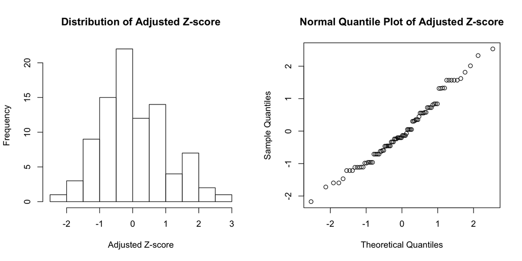

```r
# Set 1x2 plot grid
par(mfrow=c(1,2))
# Histogram for adjusted Z-score
hist(adjust_Z, main = "Distribution of Adjusted Z-score", xlab = "Adjusted Z-score")
# Normal Quantile Plot adjusted Z-score
qqnorm(adjust_Z, main = "Normal Quantile Plot of Adjusted Z-score")
```

```r
# Reset the plot grid setting
dev.off()
```

```r
empirical_rule(adjust_Z)
```

```
##             Sample Proportion (%) Theoretical Proportion (%)
## within 1 SD              67.77778                       68.0
## within 2 SD              95.55556                       95.0
## within 3 SD             100.00000                       99.7
```

**Answer**: Based on both plots and the result from `empirical_rule()` function, we can say the values $Z$ is approximately normal

# Question 3

## (a)

```r
confidence_interval = function(data, alpha){
  n = length(data)
  mean_ = mean(data)
  sd_ = sd(data)
  z = qt(1-alpha/2, n-1)

  return(c(mean_ - z*sd_/sqrt(n), mean_ + z*sd_/sqrt(n)))
}
```

## (b)

**Confidence Interval for Passengers = 4**

```r
# Confidence Interval for Passengers = 4
confidence_interval(data = Cars93[Cars93$Passengers == 4,'MPG.city'], alpha = 0.05)
```

```
## [1] 23.24665 29.88379
```

**Confidence Interval for Passengers = 5**

```r
# Confidence Interval for Passengers = 5
confidence_interval(data = Cars93[Cars93$Passengers == 5,'MPG.city'], alpha = 0.05)
```

```
## [1] 21.55777 24.05199
```

**Confidence Interval for Passengers = 6**

```r
# Confidence Interval for Passengers = 6
confidence_interval(data = Cars93[Cars93$Passengers == 6,'MPG.city'], alpha = 0.05)
```

```
## [1] 18.25713 20.29842
```

**Confidence Interval for Passengers = 7**

```r
# Confidence Interval for Passengers = 7
confidence_interval(data = Cars93[Cars93$Passengers == 7,'MPG.city'], alpha = 0.05)
```

```
## [1] 16.38464 18.11536
```

## (c)

We also know that if a level $1 - \alpha$ confidence interval for a mean doesn’t contain $0$, we can reject the null hypothesis $H_o: \mu = 0$. Then we can certainly say we now reject $H_m: \mu_1 -\mu_2 = 0 \Leftrightarrow H_o: \mu_1 = \mu_2$

## (d)

```r
# Two sample t-test
t.test(Cars93[Cars93$Passengers == 4,'MPG.city'],
       Cars93[Cars93$Passengers == 5,'MPG.city'],
       var.equal = FALSE)
```

```
##
##  Welch Two Sample t-test
##
## data:  Cars93[Cars93$Passengers == 4, "MPG.city"] and Cars93[Cars93$Passengers == 5, "MPG.city"]
## t = 2.1926, df = 28.68, p-value = 0.0366
## alternative hypothesis: true difference in means is not equal to 0
## 95 percent confidence interval:
##  0.2510077 7.2696710
## sample estimates:
## mean of x mean of y
##  26.56522  22.80488
```

**Answer**: Because the p-value is 0.0366, which is smaller than 0.05, we can reject the null hypothesis. The result does not contradict with part(b)

# Question 4

## (a)

$H_o: 4 \cdot \mu_4 = 5 \cdot \mu_5$

$H_a: 4 \cdot \mu_4 \ne 5 \cdot \mu_5$

## (b)

```r
# Obtain values of PMPG for m = 4, m = 5
PMPG_4 = 4 * Cars93[Cars93$Passengers == 4,'MPG.city']
PMPG_5 = 5 * Cars93[Cars93$Passengers == 5,'MPG.city']

t.test(PMPG_4, PMPG_5, var.equal = FALSE)
```

```
##
##  Welch Two Sample t-test
##
## data:  PMPG_4 and PMPG_5
## t = -1.0926, df = 32.447, p-value = 0.2826
## alternative hypothesis: true difference in means is not equal to 0
## 95 percent confidence interval:
##  -22.229129   6.702088
## sample estimates:
## mean of x mean of y
##  106.2609  114.0244
```

## (c)

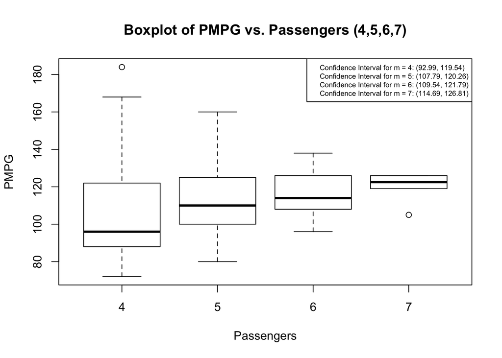

```r
conf_4 = confidence_interval(4*Cars93[Cars93$Passengers == 4,'MPG.city'],0.05)
conf_5 = confidence_interval(5*Cars93[Cars93$Passengers == 5,'MPG.city'],0.05)
conf_6 = confidence_interval(6*Cars93[Cars93$Passengers == 6,'MPG.city'],0.05)
conf_7 = confidence_interval(7*Cars93[Cars93$Passengers == 7,'MPG.city'],0.05)

boxplot(
  Passengers*MPG.city ~ Passengers,
  data = newdata,
  main = 'Boxplot of PMPG vs. Passengers (4,5,6,7)',
  xlab = 'Passengers',
  ylab = 'PMPG'
  )

legend(
  'topright',
  legend = c(
  paste('Confidence Interval for m = 4: (',
        round(conf_4[1],2), ', ',
        round(conf_4[2],2), ')', sep = ''),
  paste('Confidence Interval for m = 5: (',
        round(conf_5[1],2), ', ',
        round(conf_5[2],2), ')', sep = ''),
  paste('Confidence Interval for m = 6: (',
        round(conf_6[1],2), ', ',
        round(conf_6[2],2), ')', sep = ''),
  paste('Confidence Interval for m = 7: (',
        round(conf_7[1],2), ', ',
        round(conf_7[2],2), ')', sep = '')
  ),
  cex = 0.6
)
```

**Answer**: The means of PMPG seem to be the same between different car classes but the variations within different classes are not the same.